# Explore and Summarize Data/Red Wine Analysis

# Univariate Analysis

## Structure of dataset

wineQualityReds.csv is consist of around 1600 wines and its 12 attributes. I see that most of wines are 3 and 4 quality.

## Analysis / distribution of wine’s quality

- Mose of wine’s quality is 3 and 4
- The number of other wine’s quality are small count than quality 3 and 4

## Boxplot of pH/quality

- Most fo wine’s are in the range of pH 3.2 ~ 3.4

- Most of wine’s chlorides is less than 0.1

## Boxplot of sulphates

- Many wine’s sulphates is less than 0.75

# Bivariate Plots Section

There are some attributes which we don’t analyze yet, they are chlorides, sulphates, alcohol and density.

## Summary of chlorides as per quality

According summary() of chlorides as per quality, it seems that it is relaive with quality

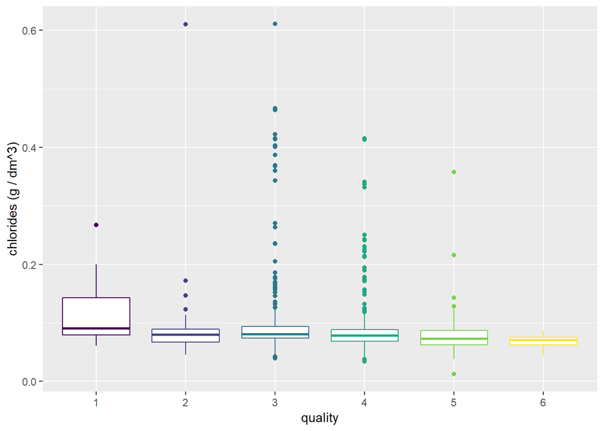

## Summary of sulphates as per quality

According summary() of sulphates as per quality, it seems that it is relaive with quality

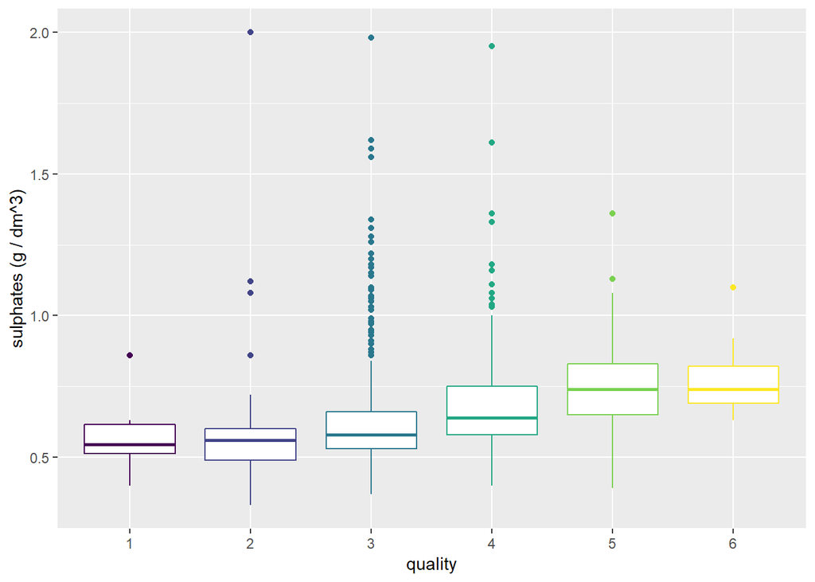

## Relationship between chlorides and sulphates

Here is a relationship between chlorides and sulphates, it seems that there are some outlier.

- Most of wine’s sulphates is < 1.0
- Most of wine’s chlorides is < 0.15

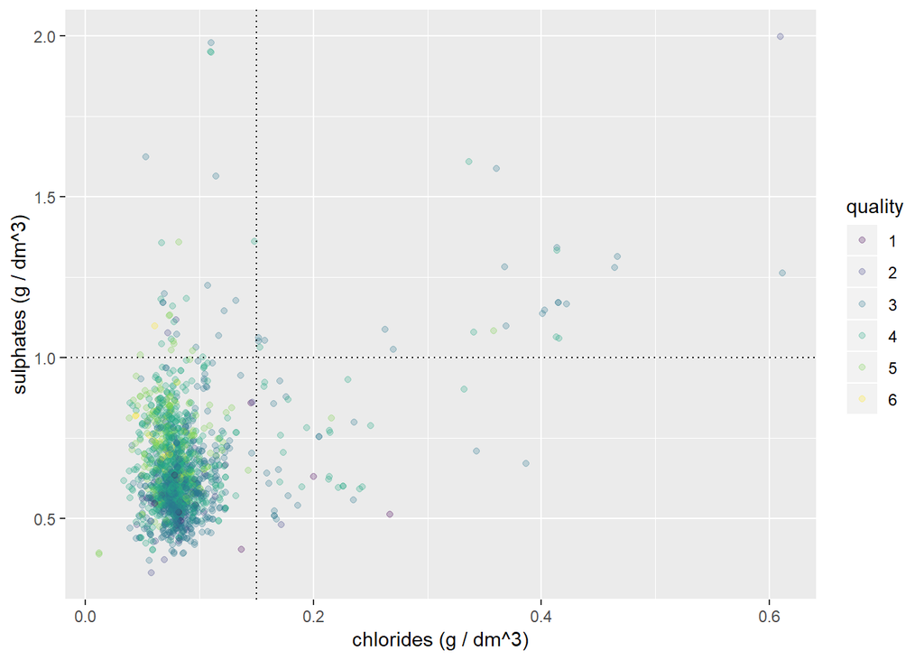

Before we remove outliers, it seems that chlorides and sulphates have weak positive relationship.

```r
cor.test(wine$chlorides, wine$sulphates)
```

```
##
##  Pearson's product-moment correlation
##
## data:  wine$chlorides and wine$sulphates
## t = 15.978, df = 1597, p-value < 2.2e-16
## alternative hypothesis: true correlation is not equal to 0
## 95 percent confidence interval:
##  0.3282127 0.4127694
## sample estimates:
##       cor
## 0.3712605
```

After we remove outliers, however, we can’t see particular relationship from scattrer plot, between chlorides and sulphates. It is not easy to observe the difference as per quality. It will be revisited in ‘Final plot’

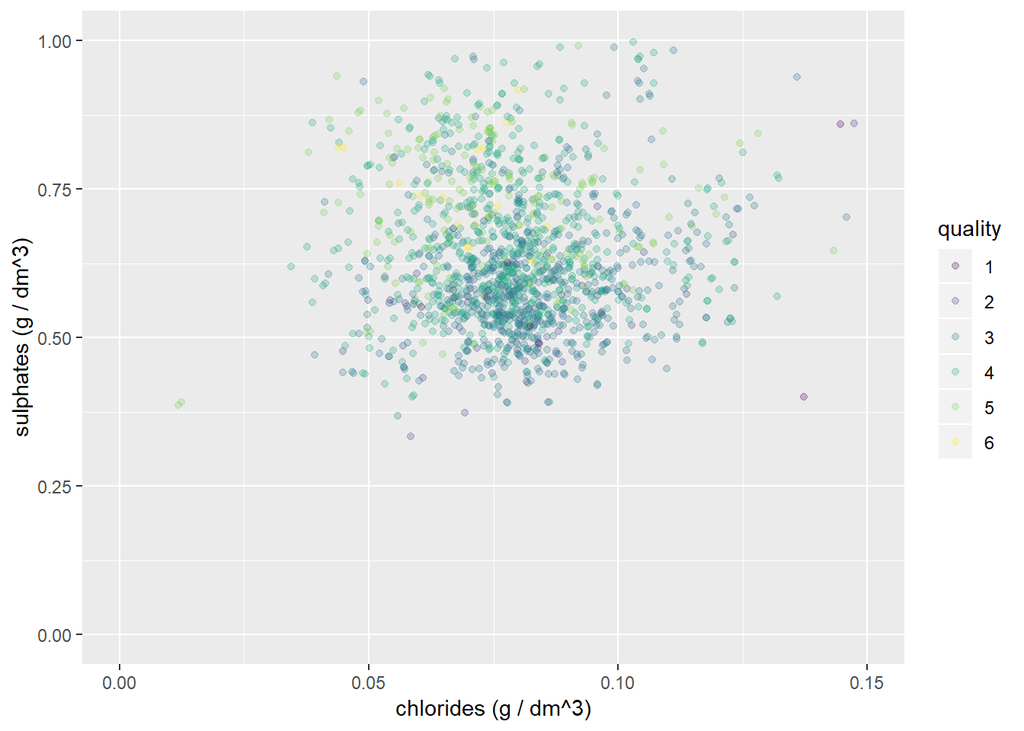

We calculate again without outliers, now, we can see that chlorides and sulphates have no relationship.

```r
wine2 = subset(wine, (chlorides < 0.15) & (sulphates < 1))

cor.test(wine2$chlorides, wine2$sulphates)
```

```
##
##  Pearson's product-moment correlation
##
## data:  wine2$chlorides and wine2$sulphates
## t = -0.47664, df = 1496, p-value = 0.6337
## alternative hypothesis: true correlation is not equal to 0
## 95 percent confidence interval:
##  -0.06293036  0.03834876
## sample estimates:
##        cor
## -0.0123224
```

## Distribution as per volatile.acidity and qualtiy

As we can see plot below, volatile.acidity have a negative relationship with quality.

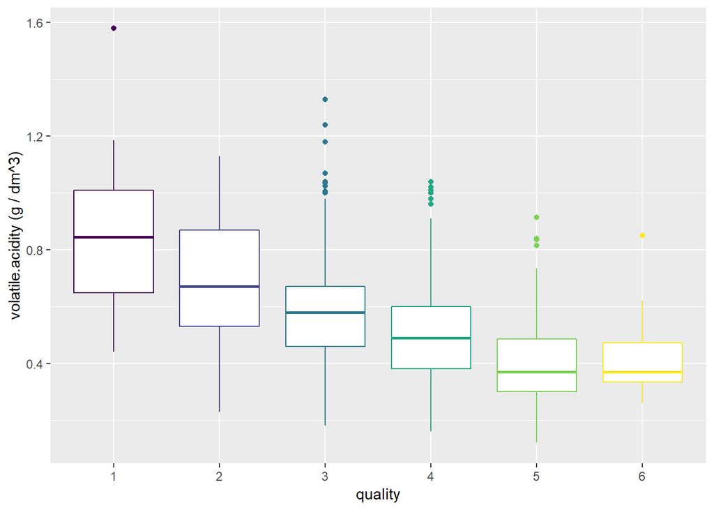

## Distribution as per fixed.acidity and qualtiy

As we can see plot below, fixed.acidity have no particular relationship with quality.

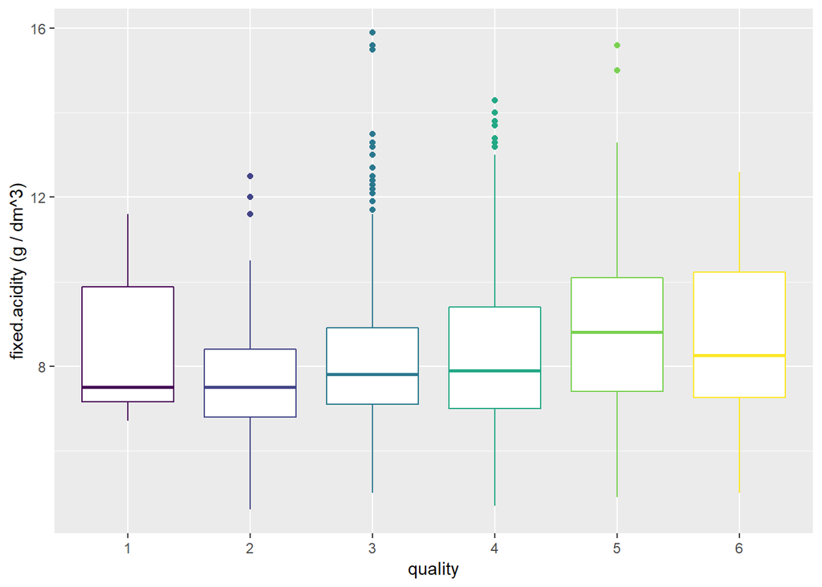

## Distribution as per citric.acid and qualtiy

As we can see plot below, citric.acid have a positive relationship with quality.

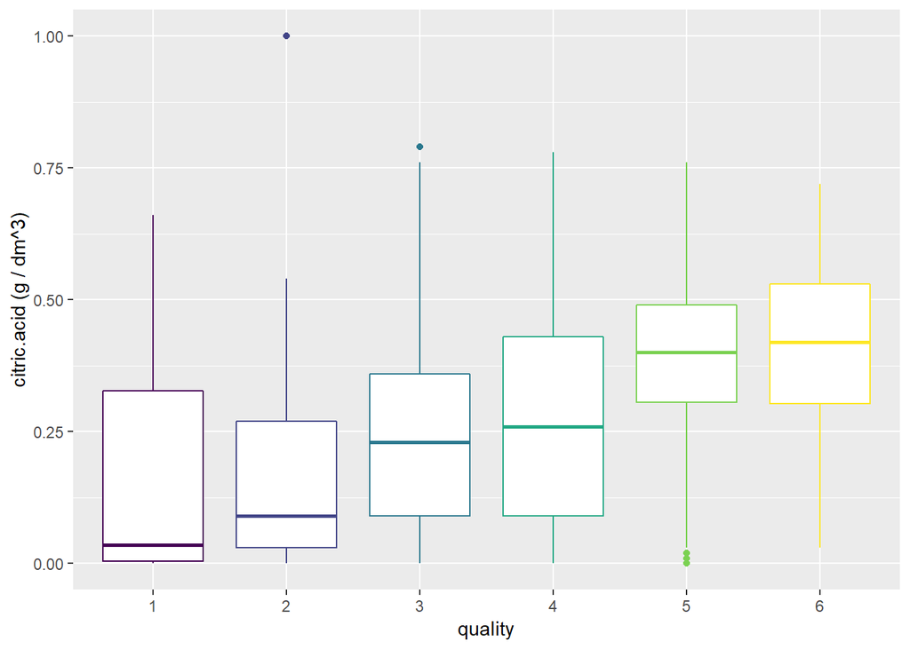

## Distribution as per volatile.acidity/citric.acid and qualtiy

As we observed that volatile.acidity and citric.acid have certain relationship(negative and positive) with quality I think that we can put them all together in one plot

- As volatile.acidity is negative relationship, X -1, to point upper-right, just to easy to understand

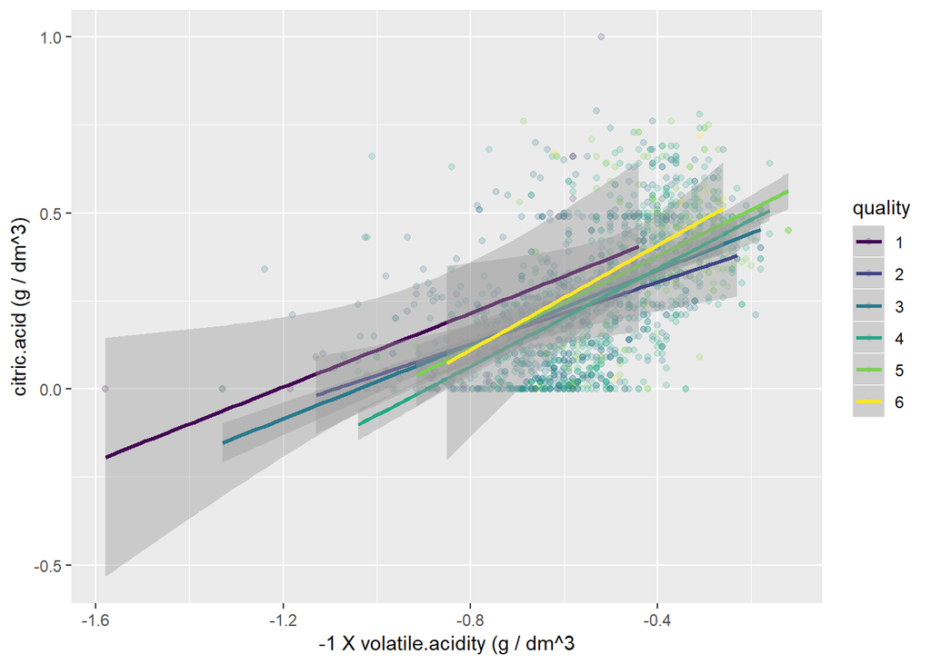

- Adding boxplot to know citric.acid movement as per higher quality

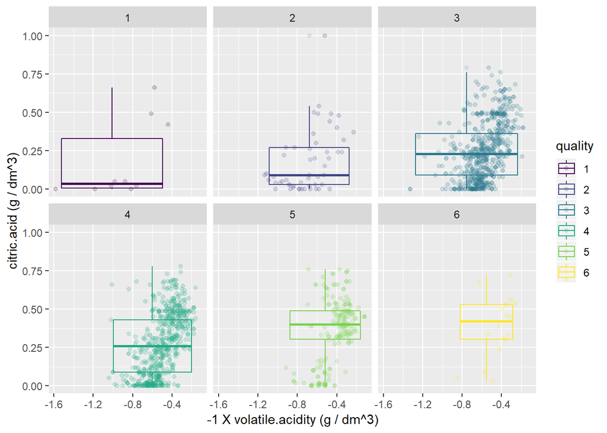

## Relationship between alcohol and density

As alcohol is getting higher, density is getting lower

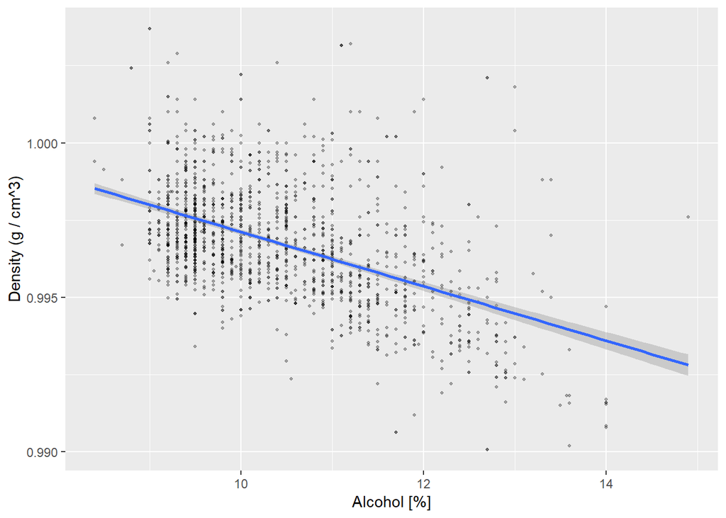

```r
cor.test(wine$alcohol, wine$density)
```

```
##
##  Pearson's product-moment correlation
##
## data:  wine$alcohol and wine$density
## t = -22.838, df = 1597, p-value < 2.2e-16
## alternative hypothesis: true correlation is not equal to 0
## 95 percent confidence interval:
##  -0.5322547 -0.4583061
## sample estimates:
##        cor
## -0.4961798
```

To observe that same negative relationship is observed after it is grouped by quality * We could observe that same negative relationship in all of quality

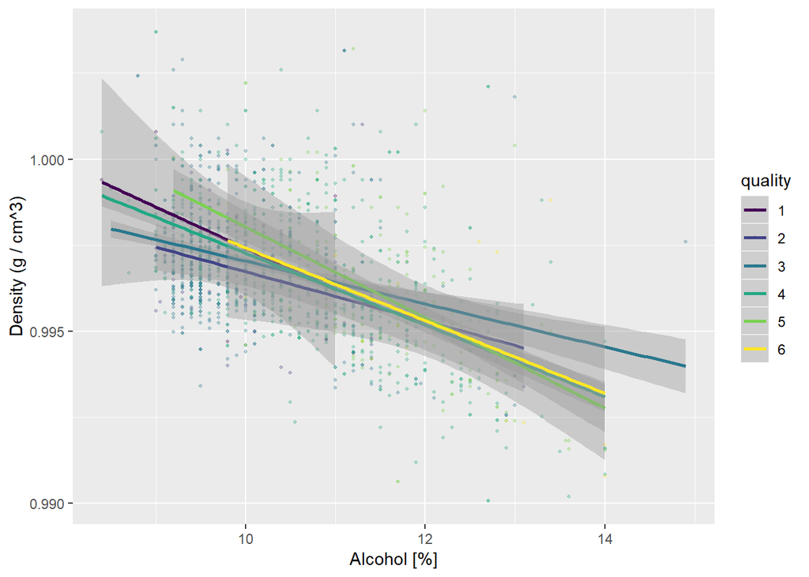

To observe cleary as per grouped by quality

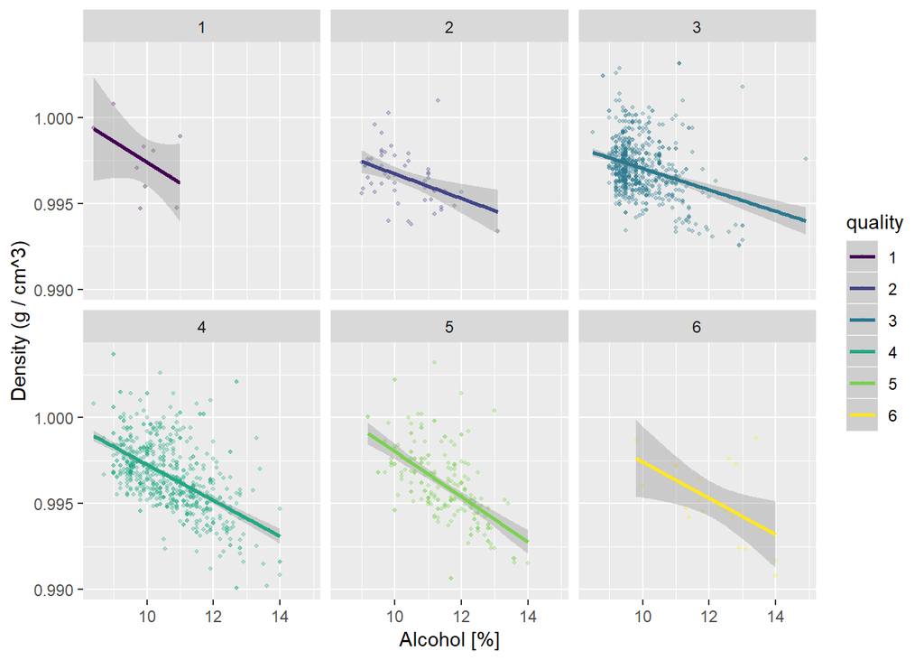

Calculated correlation of alcohol/density, as per quality

```r
w6 = subset(wine, quality == 6)
print('correlation alcohol/density of Quality 6')
```

```
## [1] "correlation alcohol/density of Quality 6"
```

```r
cor.test(w6$alcohol, w6$density)
```

```
##
##  Pearson's product-moment correlation
##
## data:  w6$alcohol and w6$density
## t = -2.5897, df = 16, p-value = 0.01975
## alternative hypothesis: true correlation is not equal to 0
## 95 percent confidence interval:
##  -0.8058649 -0.1026367
## sample estimates:
##       cor
## -0.543465
```

```r
w5 = subset(wine, quality == 5)
print('correlation alcohol/density of Quality 5')
```

```
## [1] "correlation alcohol/density of Quality 5"
```

```r
cor.test(w5$alcohol, w5$density)
```

```
##
##  Pearson's product-moment correlation
##
## data:  w5$alcohol and w5$density
## t = -10.038, df = 197, p-value < 2.2e-16
## alternative hypothesis: true correlation is not equal to 0
## 95 percent confidence interval:
##  -0.6668522 -0.4815944
## sample estimates:
##       cor
## -0.581718
```

```r
w4 = subset(wine, quality == 4)
print('correlation alcohol/density of Quality 4')
```

```
## [1] "correlation alcohol/density of Quality 4"
```

```r
cor.test(w4$alcohol, w4$density)
```

```
##
##  Pearson's product-moment correlation
##
## data:  w4$alcohol and w4$density
## t = -16.484, df = 636, p-value < 2.2e-16
## alternative hypothesis: true correlation is not equal to 0
## 95 percent confidence interval:
##  -0.5992936 -0.4903238
## sample estimates:
##        cor
## -0.5471226
```

```r
w3 = subset(wine, quality == 3)
print('correlation alcohol/density of Quality 3')
```

```
## [1] "correlation alcohol/density of Quality 3"
```

```r
cor.test(w3$alcohol, w3$density)
```

```
##
##  Pearson's product-moment correlation
##
## data:  w3$alcohol and w3$density
## t = -7.8593, df = 679, p-value = 1.518e-14
## alternative hypothesis: true correlation is not equal to 0
## 95 percent confidence interval:
##  -0.3561655 -0.2183697
## sample estimates:
##        cor
## -0.2887623
```

```r
w2 = subset(wine, quality == 2)
print('correlation alcohol/density of Quality 2')
```

```
## [1] "correlation alcohol/density of Quality 2"
```

```r
cor.test(w2$alcohol, w2$density)
```

```
##
##  Pearson's product-moment correlation
##
## data:  w2$alcohol and w2$density
## t = -3.3461, df = 51, p-value = 0.001544
## alternative hypothesis: true correlation is not equal to 0
## 95 percent confidence interval:
##  -0.6231186 -0.1739388
## sample estimates:
##       cor
## -0.424285
```

```r
w1 = subset(wine, quality == 1)
print('correlation alcohol/density of Quality 1')
```

```
## [1] "correlation alcohol/density of Quality 1"
```

```r
cor.test(w1$alcohol, w1$density)
```

```
##
##  Pearson's product-moment correlation
##
## data:  w1$alcohol and w1$density
## t = -1.5924, df = 8, p-value = 0.15
## alternative hypothesis: true correlation is not equal to 0
## 95 percent confidence interval:
##  -0.8558534  0.2011769
## sample estimates:
##        cor
## -0.4905907
```

This plot is to know alcohol/density as per quality, including boxplot of alcohol, to compare alcohol as per quality

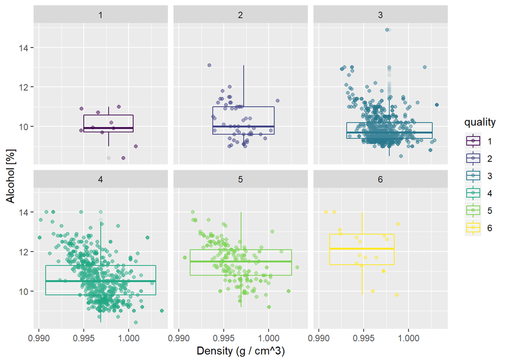

```r
ggplot(wine, aes(x=density, y=alcohol, color=quality)) +
  facet_wrap(~quality) +
  geom_point(alpha=0.5) +
  geom_boxplot(alpha=0.1) +
  ylab('Alcohol [%]') +
  xlab('Density (g / cm^3)')
```

# Bivariate Analysis

## Main interest in dataset

We are going to analysis how each columns impact on wine quality, and relationship between some columns.

- There are three acidity, volatile.acidity, fixed.acidity and citric.acid.
- In the plots above, each acidity impact on quality differently.
- Relationship between chlorides and sulphates
- Relationship between alcohol and density

### sulphates and quality

Higher sulphates is observed in higher quality wine

### chlorides and quality

lower chlorides is observed in higher quality wine

## Relationship between chlorides and sulphates

- We might confused that chlorides and sulphates have weak positive relationship
- However, after we removed outliers, there is no particular relation between them

## Hypothesis and initial guessing regarding acidity and quality

Before I analyze ‘wineQualityReds.csv’ data, my initial guessing is like below

- As per increasing acidity, quality is increased
- If acidity is over certain level, its impact is changed to negative

Hoever, the impact on quality is different as per each acidity. Even one of them, don’t impact on quality

## Analyzed relationship between quality and each acidity

Unlike initial guessing, each acidity have different impact on quality.

- volatile.acidity, have a negative relationship with quality
- fixed.acidity, seems that it don’t impact on quality
- citric.acid, have a positive relationship with quality

## Analyzed distribution/relationship as per volatile.acidity/citric.acid and qualtiy

- All quality of wine, volatile.acidity/citric have negative relationship

### Unusal distribution of fixed.acidity/quality

Other acidity(volatile.acidity and citric.acid) have certain relationship regarding quality. Even fixed.acidity is one of acidity, it seems that it is not relative with quality

## Relationship between alcohol and density

- It is observed that alcohol and density have negative relationship
- Quality 6 have higher alcohol than other quality

# Multivariate Plots Section

Previous bivariate analysis, we couldn’t find particular relationship between chlorides and sulphates. However, it seems that they are still relative with quality. So, we are going to figure it out.

## How chlorides and sulphates impact on quality

If we group chlorides and sulphates as per quality, We could observe that there is a relationship regarding chlorides/sulphates and qulaity.

```
## [1] "chlorides summary of Quality 6"
```

```
##    Min. 1st Qu.  Median    Mean 3rd Qu.    Max.
## 0.04400 0.06500 0.07100 0.06888 0.07600 0.08600
```

```
## [1] "chlorides summary of Quality 5"
```

```
##    Min. 1st Qu.  Median    Mean 3rd Qu.    Max.
## 0.01200 0.06200 0.07200 0.07442 0.08700 0.14300
```

```
## [1] "chlorides summary of Quality 4"
```

```
##    Min. 1st Qu.  Median    Mean 3rd Qu.    Max.
## 0.03400 0.06800 0.07800 0.07808 0.08600 0.13200
```

```
## [1] "chlorides summary of Quality 3"
```

```
##    Min. 1st Qu.  Median    Mean 3rd Qu.    Max.
## 0.03900 0.07400 0.08000 0.08245 0.09000 0.14600
```

```
## [1] "chlorides summary of Quality 2"
```

```
##    Min. 1st Qu.  Median    Mean 3rd Qu.    Max.
## 0.04500 0.06700 0.07900 0.07902 0.08800 0.14700
```

```
## [1] "chlorides summary of Quality 1"
```

```
##    Min. 1st Qu.  Median    Mean 3rd Qu.    Max.
## 0.06100 0.07700 0.08300 0.09475 0.10700 0.14500
```

On the contrary, if sulphate goes higher, as quality is higher.

```r
summary(wine_6$sulphates)
```

```
##    Min. 1st Qu.  Median    Mean 3rd Qu.    Max.
##  0.6300  0.6900  0.7400  0.7482  0.8200  0.9200
```

```r
summary(wine_5$sulphates)
```

```
##    Min. 1st Qu.  Median    Mean 3rd Qu.    Max.
##  0.3900  0.6500  0.7300  0.7241  0.8100  0.9900
```

```r
summary(wine_4$sulphates)
```

```
##    Min. 1st Qu.  Median    Mean 3rd Qu.    Max.
##  0.4000  0.5700  0.6400  0.6569  0.7300  0.9900
```

```r
summary(wine_3$sulphates)
```

```
##    Min. 1st Qu.  Median    Mean 3rd Qu.    Max.
##  0.3700  0.5200  0.5800  0.5919  0.6400  0.9900
```

```r
summary(wine_2$sulphates)
```

```
##    Min. 1st Qu.  Median    Mean 3rd Qu.    Max.
##  0.3300  0.4900  0.5600  0.5496  0.5900  0.8600
```

```r
summary(wine_1$sulphates)
```

```
##    Min. 1st Qu.  Median    Mean 3rd Qu.    Max.
##  0.4000  0.5125  0.5450  0.5700  0.5850  0.8600
```

## Distribution of chlorides/sulphates as per quality

According two plot above, it seems that chlorides/sulphates have a relationship with quality. This plot is to show it together. However, it is still not easy to know it from plot, we will revisit it in ‘Final plot’

- As chlorides is negative relationship with quality, we multiply * -1
- It is to located wines, sulphates to upper-right as it have lower chlorides

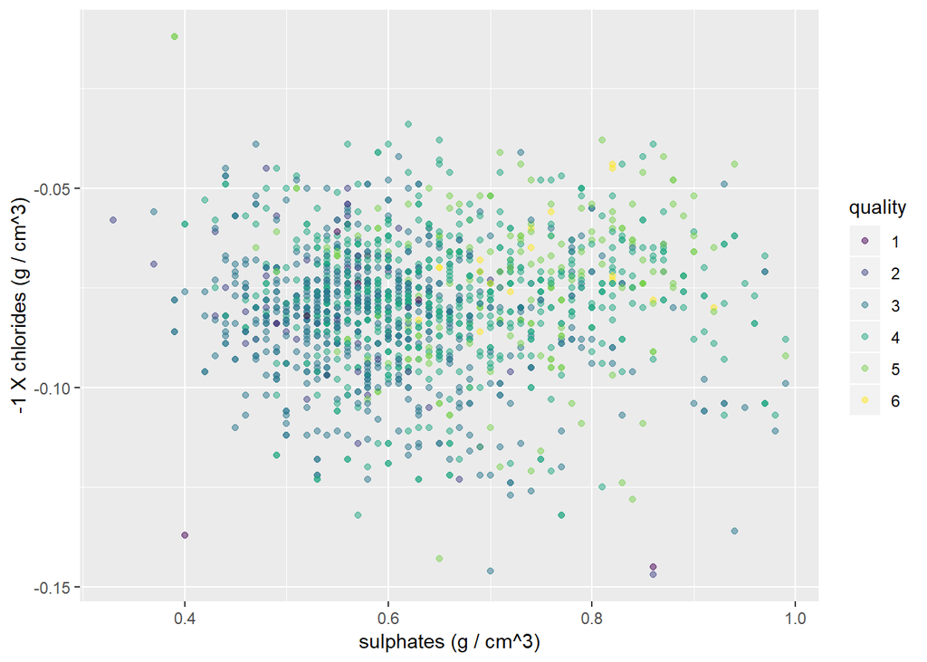

- Still not easy to observe relationship between quality and chlorides/sulphates
- To observe more, it is grouped by quality
- It seems that they have some distribution as per quality

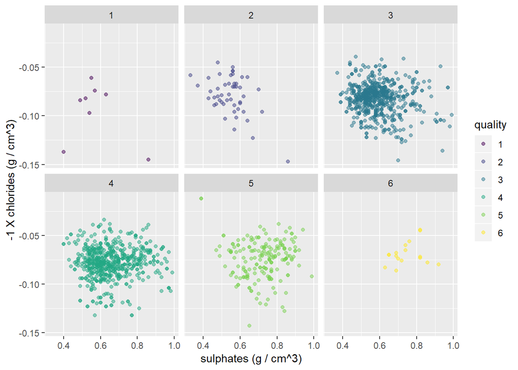

- To observe trend of chlorides/sulphates, add trend line by using geom_smooth()
- Observed that inclination is changing as per quality
- it is changed to positive as per higher quality

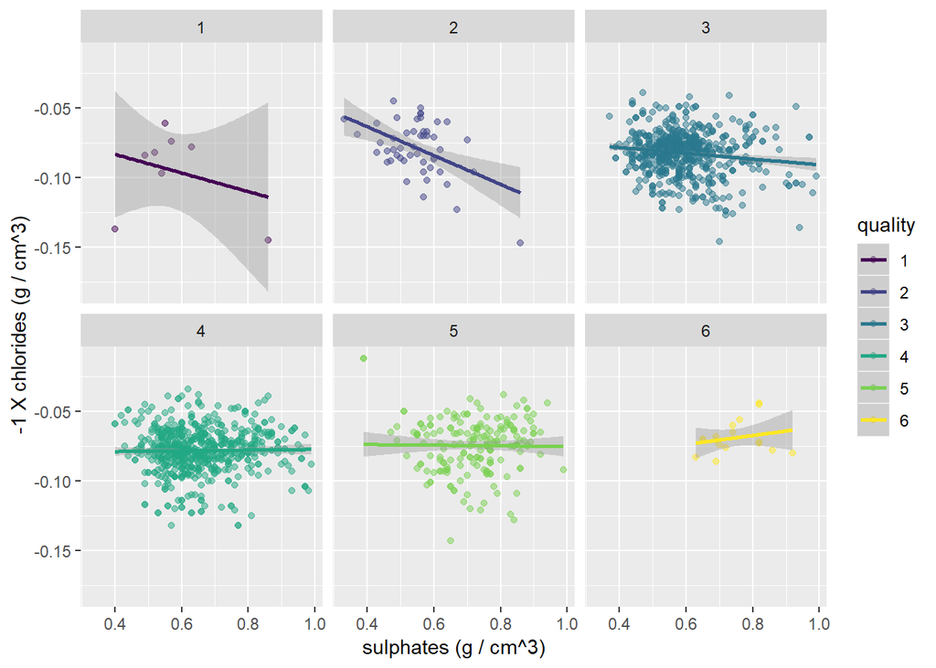

# Multivariate Analysis

## Quality is related with chlorides and sulphates

In previous Bivariate Analysis, it seems that chlorides and sulphates have no relationship. However, after we remove outliers of chlorides and sulphates, we could observe that it impact on quality.

- However, not easy to know it from plot relationship quality and chlorides/sulphates

## Analysis/Distribution of chlorides/sulphates as per quality

The trend of chlorides/sulphates is changed as per quality. As quality is goes higher, it is moved to positive from negative

# Final Plot and Summary

## Wine quality and volatile.acidity/citric.acid

- Quality goes higher, both volatile.acidity/citric.acid goes to narrow range
- Quality 3, 4 have wide range of volatile.acidity/citric.acid
- As volatile.acidity is negative relationship with quality, we multiply * -1, to locate to upper-right

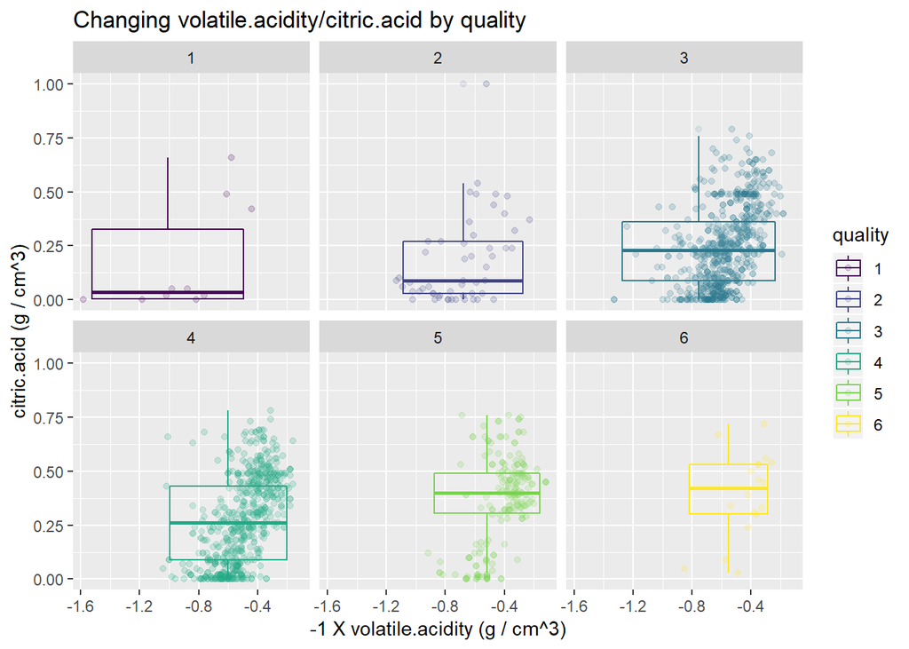

## Wine quality and alcohol/density

- Higher alcohol percetage in quality 6
- Quality 3, 4 and 5, have wide range of density/alcohol

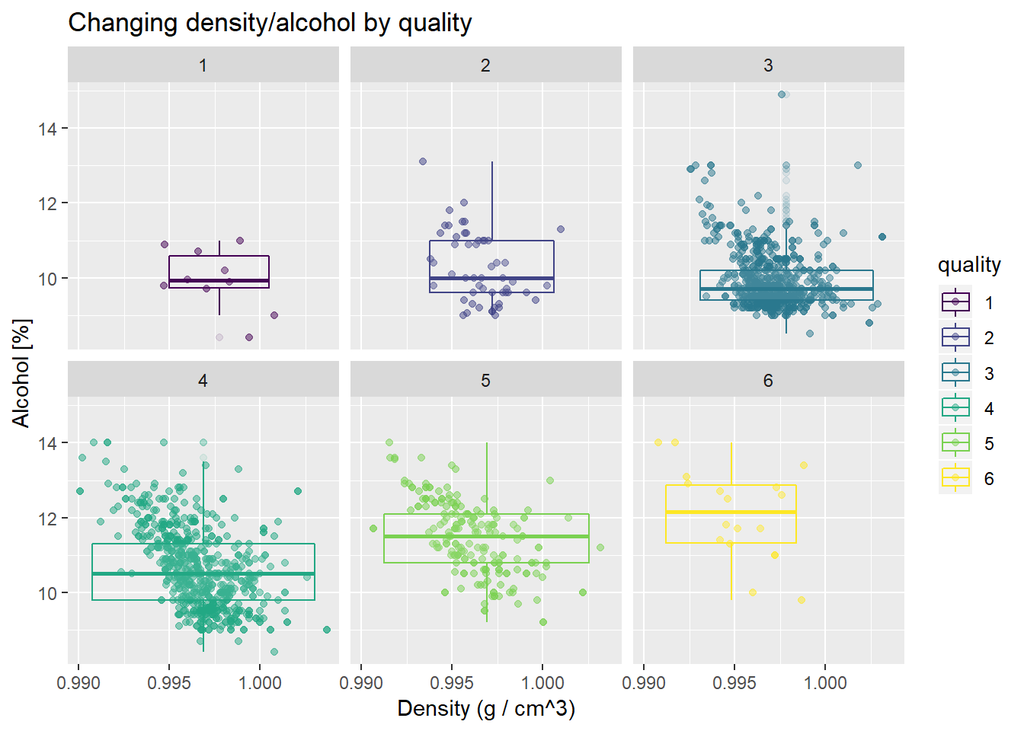

## Wine quality and chlorides/sulphates

[figure not shown]

# Reflection

## Ratio of chlorides/sulphates for better quality

- Hope to understand more regarding ratio of chlorides/sulphates to be better quality
- However, the number of higher quality wine, is too smal to analyze it

## Hard to find rule of quality

- We found some point what make wine’s quality is better
- Not easy to figure out particular rule of wine’s quality
- It seems there is a kind of combination of attributes to define quality

## Hard to draw plot what I want

- In Final Plot, I hope to draw line between mean/median as per different quality
- After I spent over few hours, I realized that it is not possible